# checkpoint 3

Author

Amanda Dong, Zita Tam, Natalie Carthwright, Aryan Nair

## Country GDP API

Setting my API ninja key!! (code hidden)

load in packages and dataset:

```r
library(httr)
library(tidyjson)
library(jsonlite)
library(tidyverse)
library(stringr)
cases_month <- readr::read_csv('https://raw.githubusercontent.com/rfordatascience/tidytuesday/main/data/2025/2025-06-24/cases_month.csv')
cases_year <- readr::read_csv('https://raw.githubusercontent.com/rfordatascience/tidytuesday/main/data/2025/2025-06-24/cases_year.csv')
```

**Example with Canada 2026**

To start, I am going to use the API to access the GDP data for Canada in 2026.

```r
base_url <- "https://api.api-ninjas.com/v1/gdp"
country <- "Canada"
year <- "2026"
url <- str_c(base_url, "?country=", country, "&year=", year)
canada_raw <- GET(url, add_headers("X-Api-Key" = my_key))
```

We now have the raw data, so I will change it into JSON format and parse in to a tidy dataframe.

```r
canada_data <- rawToChar(canada_raw$content)
canada_tidy <- fromJSON(canada_data)
canada_final <- canada_tidy %>% select(country, year, gdp_per_capita_nominal)
```

**Writing function**

Next, using the methods we used for Canada as a blueprint, I’ll create a function to get the data for all countries.

```r
get_gdp_data <- function(country, year, key = my_key) {
  if (is.na(country) || is.na(year)) {
    return(NULL)
  }

  country <- str_replace_all(country, " ", "%20")
  base_url <- "https://api.api-ninjas.com/v1/gdp"
  url <- str_c(base_url, "?country=", country, "&year=", year)
  raw_data <- GET(url, add_headers("X-Api-Key" = my_key))
  json_data <- rawToChar(raw_data$content)
  tidy_data <- fromJSON(json_data)
  if (!is.data.frame(tidy_data) || nrow(tidy_data) == 0) {
    return(NULL)
  }
  if (!"gdp_per_capita_nominal" %in% names(tidy_data) ||
      is.na(tidy_data$gdp_per_capita_nominal)) {
    return(tibble(
      country = country,
      year = year,
      gdp_per_capita_nominal = NA
    ))
  }
  gdps <- tidy_data %>% select(country, year, gdp_per_capita_nominal)
}
```

Let’s test the function using USA in 2019.

```r
get_gdp_data("United States", "2019")
get_gdp_data("hello", "yes")
```

[output not shown]

Now we need to apply the function to all countries and years in our measles data.

```r
apply_data <- cases_year %>% select(country, year) %>%
  filter(!is.na(country)) %>% filter(!is.na(year))

# results1 <- map2_dfr(.x = apply_data$country[1:500], .y = apply_data$year[1:500], .f = get_gdp_data)
# results2 <- map2_dfr(.x = apply_data$country[501:1000], .y = apply_data$year[501:1000], .f = get_gdp_data)
# results3 <- map2_dfr(.x = apply_data$country[1001:1500], .y = apply_data$year[1001:1500], .f = get_gdp_data)
# results4 <- map2_dfr(.x = apply_data$country[1501:2000], .y = apply_data$year[1501:2000], .f = get_gdp_data)
# results5 <- map2_dfr(.x = apply_data$country[2001:2380], .y = apply_data$year[2001:2380], .f = get_gdp_data)

results1$country_full <- countrycode(results1$country, origin = "iso3c", destination = "country.name")
results2$country_full <- countrycode(results2$country, origin = "iso3c", destination = "country.name")
results3$country_full <- countrycode(results3$country, origin = "iso3c", destination = "country.name")
results3[98, 4] <- "Pakistan"
results4$country_full <- countrycode(results4$country, origin = "iso3c", destination = "country.name")
results4[101:110, 4] <- "Montenegro"
results5$country_full <- countrycode(results5$country, origin = "iso3c", destination = "country.name")

GDP_APIdata <- bind_rows(results1, results2, results3, results4, results5)

# saving to CSV for future use
write.csv(GDP_APIdata, "GDPdata.csv", row.names = FALSE)
```

```r
GDP_APIdata <- read.csv("GDPdata.csv")
head(GDP_APIdata)
```

```
  country year gdp_per_capita_nominal country_full
1     DZA 2012               6057.974      Algeria
2     DZA 2013               5997.896      Algeria
3     DZA 2014               6108.878      Algeria
4     DZA 2015               4691.686      Algeria
5     DZA 2016               4426.580      Algeria
6     DZA 2017               4554.150      Algeria
```

**Brief description of new dataset**

#### Join the datasets

```r
meta_df <- cases_year |>
  left_join(GDP_APIdata, by = c("iso3" = "country", "year" = "year"))
```

#### Research Question: How does the relationship between GDP per capita and measles incidence rate change before and after COVID?

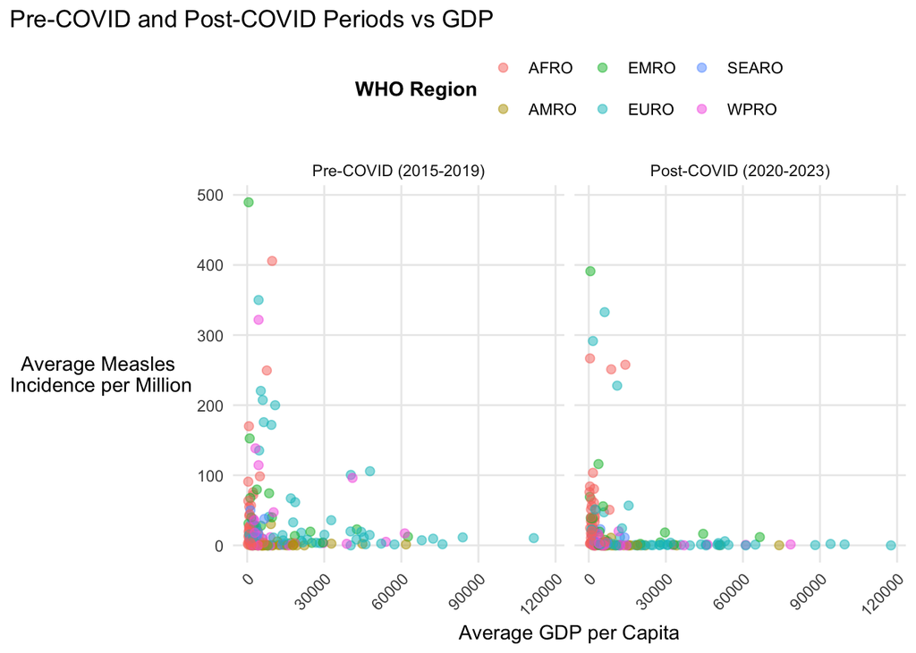

```r
meta_df |>
  mutate(
    time_period = case_when(
      year >= 2015 & year <= 2019 ~ "Pre-COVID (2015-2019)",
      year >= 2020 & year <= 2023 ~ "Post-COVID (2020-2023)"),
      time_period = factor(time_period, levels = c("Pre-COVID (2015-2019)", "Post-COVID (2020-2023)"))) |>
  filter(!is.na(time_period)) |>
  group_by(iso3, country_full, region, time_period) |>
  summarize(
    avg_incidence = mean(measles_incidence_rate_per_1000000_total_population, na.rm = TRUE),
    avg_gdp = mean(gdp_per_capita_nominal, na.rm = TRUE)) |>
  filter(!is.na(avg_incidence), !is.na(avg_gdp),
         avg_incidence < 500, avg_gdp > 0) |> #removed extreme outliers to observe differences
  ggplot(aes(x = avg_gdp, y = avg_incidence, color = region)) +
  geom_point(alpha = 0.5, size = 2) +
  facet_wrap(~time_period) +
  labs(
    title = "Pre-COVID and Post-COVID Periods vs GDP",
    x = "Average GDP per Capita",
    y = "Average Measles \nIncidence per Million",
    color = "WHO Region") +
  theme_minimal() +
  theme(plot.title = element_text(hjust = 0),
        plot.title.position = "plot",
        axis.text.x = element_text(angle = 45, hjust = 1),
        axis.title.y = element_text(angle = 0, vjust = 0.5),
        panel.grid.minor = element_blank(),
        legend.position = "top",
        legend.title = element_text(face = "bold")
        )
```

## Air Quality API

Loading in packages and datasets

```r
library(httr)
library(tidyjson)
library(jsonlite)
library(tidyverse)
library(glue)
library(lubridate)

cases_year <- read_csv('https://raw.githubusercontent.com/rfordatascience/tidytuesday/main/data/2025/2025-06-24/cases_year.csv')
```

## First acessing the API about air quality worldwide

```r
#https://api.api-ninjas.com/v1/airquality?city=New%20York%20City&country=United%20States

base_url <- "https://api.api-ninjas.com/v1/airquality?"

city <- "city=New%20York%20City"
country <- "country=United%20States"

us_url <- glue("{base_url}{city}&{country}")


us_row <- GET(us_url, add_headers("X-Api-Key" = my_key))

us_data <- fromJSON(rawToChar(us_row$content))
```

## Extracting the variable total_aqi to get the total air quality index for each country

```r
us_total <- us_data$overall_aqi

us_total
```

```
[1] 168
```

## Creating a dataset that has a city for every country in the measles dataset

```r
cases_year$country[cases_year$year == "2025"]

country_city_tbl <- tibble(
  country = c(
    "Algeria","Benin","Botswana","Burkina Faso","Burundi","Cameroon",
    "Central African Republic","Chad","Comoros","Congo","Côte d'Ivoire","Democratic Republic of the Congo","Equatorial Guinea", "Eswatini","Ethiopia","Gabon","Gambia","Ghana","Guinea","Guinea-Bissau","Kenya","Lesotho","Liberia","Madagascar","Malawi","Mali","Mauritania","Mozambique","Namibia","Niger","Nigeria","Rwanda","Senegal","Sierra Leone","South Africa","South Sudan","Togo","Uganda","United Republic of Tanzania","Zambia","Zimbabwe", "Antigua and Barbuda", "Argentina","Bahamas","Barbados","Belize","Bolivia (Plurinational State of)","Brazil","Canada","Chile","Colombia","Costa Rica","Cuba","Dominican Republic","Ecuador","El Salvador", "Guatemala","Guyana","Haiti","Honduras","Jamaica","Mexico","Nicaragua","Panama","Peru","Saint Lucia","Saint Vincent and the Grenadines", "Trinidad and Tobago","United States of America", "Afghanistan", "Bahrain","Djibouti","Iran (Islamic Republic of)","Iraq","Jordan", "Kuwait","Lebanon","Libya","Morocco","Oman","Pakistan","Qatar","Saudi Arabia","Somalia","Sudan","Syrian Arab Republic","Tunisia","United Arab Emirates","Yemen","Albania","Armenia","Austria","Azerbaijan","Belarus","Belgium","Bosnia and Herzegovina" ,"Bulgaria", "Croatia", "Cyprus", "Czechia","Denmark","Estonia","Finland","France","Georgia","Germany","Greece","Hungary","Ireland","Israel","Italy","Kazakhstan","Kyrgyzstan","Lithuania","Luxembourg","Montenegro","Netherlands (Kingdom of the)","Norway","Poland","Portugal","Republic of Moldova","Romania","Russian Federation", "Serbia", "Slovakia", "Slovenia","Spain","Sweden","Switzerland","Tajikistan","Türkiye","Turkmenistan","Ukraine","United Kingdom of Great Britain and Northern Ireland","Uzbekistan","Bangladesh","Bhutan","Democratic People's Republic of Korea","India","Indonesia","Maldives","Myanmar","Nepal","Sri Lanka","Thailand","Timor-Leste","Australia","Brunei Darussalam", "Cambodia","China","Cook Islands","Fiji","Japan","Kiribati","Lao People's Democratic Republic","Malaysia","Marshall Islands", "Micronesia (Federated States of)","Mongolia","Nauru","New Zealand","Niue","Palau","Philippines","Republic of Korea", "Singapore","Tuvalu","Viet Nam"
  ),

  city = c(
    "Algiers","Cotonou","Gaborone","Ouagadougou","Bujumbura","Douala",
    "Bangui","N'Djamena","Moroni","Brazzaville","Abidjan","Kinshasa",
    "Malabo","Mbabane","Addis Ababa","Libreville","Banjul","Accra",
    "Conakry","Bissau","Nairobi","Maseru","Monrovia","Antananarivo",
    "Lilongwe","Bamako","Nouakchott","Maputo","Windhoek","Niamey",
    "Lagos","Kigali","Dakar","Freetown","Johannesburg","Juba","Lomé",
    "Kampala","Dar es Salaam","Lusaka","Harare","St. John's","Buenos Aires","Nassau","Bridgetown","Belize City","Santa Cruz","São Paulo","Toronto","Santiago","Bogotá","San José","Havana","Santo Domingo","Guayaquil","San Salvador","Guatemala City", "Georgetown", "Port-au-Prince","Tegucigalpa","Kingston","Mexico City", "Managua", "Panama City","Lima","Castries","Kingstown","Port of Spain","New York","Kabul","Manama","Djibouti","Tehran","Baghdad","Amman","Kuwait City","Beirut","Tripoli","Casablanca","Muscat","Karachi","Doha","Riyadh","Mogadishu","Khartoum","Damascus","Tunis","Dubai","Sana'a","Tirana","Yerevan","Vienna","Baku","Minsk","Brussels","Sarajevo","Sofia","Zagreb","Nicosia","Prague","Copenhagen","Tallinn","Helsinki","Paris","Tbilisi","Berlin","Athens","Budapest","Dublin","Tel Aviv", "Rome", "Almaty","Bishkek","Vilnius","Luxembourg","Podgorica","Amsterdam","Oslo","Warsaw","Lisbon","Chișinău","Bucharest","Moscow","Belgrade","Bratislava","Ljubljana","Madrid","Stockholm","Zurich","Dushanbe","Istanbul","Ashgabat","Kyiv","London","Tashkent","Dhaka","Thimphu","Pyongyang","Mumbai","Jakarta","Malé","Yangon","Kathmandu","Colombo","Bangkok","Dili","Sydney","Bandar Seri Begawan","Phnom Penh","Shanghai","Avarua",
"Suva","Tokyo","Tarawa","Vientiane","Kuala Lumpur","Majuro","Palikir",
"Ulaanbaatar","Yaren","Auckland","Alofi","Ngerulmud","Manila","Seoul",
"Singapore","Funafuti","Ho Chi Minh City"
  ))
```

## Creating a function to extract total_aqi for each country

```r
get_aqi <- function(city, country){

  base_url <- "https://api.api-ninjas.com/v1/airquality?"

  city <- paste0("city=", gsub(" ", "%20", city))

  country <- paste0("country=", gsub(" ", "%20", country))

  my_url <- glue("{base_url}{city}&{country}")

  my_key = "r28T1kQCHLHvPuqrJm8YnCgtmMyQJWiKcuYyuz9u"

  my_row <- GET(my_url, add_headers("X-Api-Key" = my_key))

  my_data <- fromJSON(rawToChar(my_row$content))

  if (length(my_data$overall_aqi) == 0){

    my_total_aqi <- NA

  }else {

    my_total_aqi <- my_data$overall_aqi

  }

  return(my_total_aqi)

}
```

## Testing the function on Algiers, Algeria

```r
get_aqi("Algiers", "Algeria")
```

```
[1] 84
```

## Running the function over the full dataset and creating a new data frame

```r
first_run <- map2(.x = country_city_tbl$city, .y = country_city_tbl$country, .f = ~get_aqi(city = .x, country = .y))

aqi_df <- data.frame(total_aqi = unlist(first_run))

nrow(country_city_tbl)
nrow(aqi_df)

new <- cbind(country_city_tbl, aqi_df)
new

write.csv(new, "new.csv")
```

## Data description

This is a data frame that contains every total Air Quality Index by city and country in the year 2025. There are 168 rows for the 168 countries in the measles data but two cities have no data: Niamey, Niger and Seoul, Republic of Korea.

## Meta Dataset

```r
new <- read.csv("new.csv")
results_clean <- GDP_APIdata %>%
  select(country = country_full, year, gdp_per_capita_nominal)

meta_df <- cases_year %>%
  left_join(new, by = "country") %>%
  left_join(results_clean, by = c("country", "year"))

head(meta_df)
```

```
# A tibble: 6 × 23
  region country iso3   year total_population annualized_population_most_recen…¹
  <chr>  <chr>   <chr> <dbl>            <dbl>                              <dbl>
1 AFRO   Algeria DZA    2012         37646166                           37646166
2 AFRO   Algeria DZA    2013         38414172                           38414172
3 AFRO   Algeria DZA    2014         39205031                           39205031
4 AFRO   Algeria DZA    2015         40019529                           40019529
5 AFRO   Algeria DZA    2016         40850721                           40850721
6 AFRO   Algeria DZA    2017         41689299                           41689299
# ℹ abbreviated name: ¹annualized_population_most_recent_year_only
# ℹ 17 more variables: total_suspected_measles_rubella_cases <dbl>,
#   measles_total <dbl>, measles_lab_confirmed <dbl>, measles_epi_linked <dbl>,
#   measles_clinical <dbl>,
#   measles_incidence_rate_per_1000000_total_population <dbl>,
#   rubella_total <dbl>, rubella_lab_confirmed <dbl>, rubella_epi_linked <dbl>,
#   rubella_clinical <dbl>, …
```

```r
names(meta_df)
```

```
 [1] "region"
 [2] "country"
 [3] "iso3"
 [4] "year"
 [5] "total_population"
 [6] "annualized_population_most_recent_year_only"
 [7] "total_suspected_measles_rubella_cases"
 [8] "measles_total"
 [9] "measles_lab_confirmed"
[10] "measles_epi_linked"
[11] "measles_clinical"
[12] "measles_incidence_rate_per_1000000_total_population"
[13] "rubella_total"
[14] "rubella_lab_confirmed"
[15] "rubella_epi_linked"
[16] "rubella_clinical"
[17] "rubella_incidence_rate_per_1000000_total_population"
[18] "discarded_cases"
[19] "discarded_non_measles_rubella_cases_per_100000_total_population"
[20] "X"
[21] "city"
[22] "total_aqi"
[23] "gdp_per_capita_nominal"
```

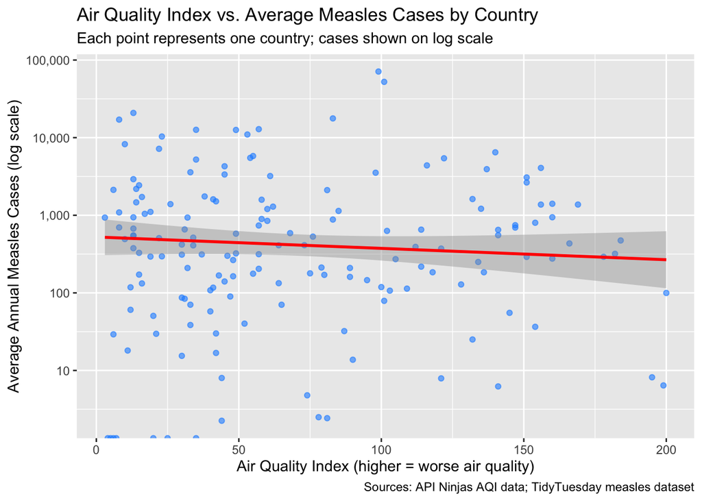

```r
meta_df %>%
  filter(!is.na(total_aqi), !is.na(total_suspected_measles_rubella_cases)) %>%
  group_by(country, total_aqi) %>%
  summarise(avg_cases = mean(total_suspected_measles_rubella_cases, na.rm = TRUE)) %>%
  ggplot(aes(x = total_aqi, y = avg_cases)) +
  geom_point(alpha = 0.6, color = "dodgerblue") +
  geom_smooth(method = "lm", se = TRUE, color = "red") +
  scale_y_log10(labels = scales::comma) +
  labs(
    title = "Air Quality Index vs. Average Measles Cases by Country",
    subtitle = "Each point represents one country; cases shown on log scale",
    x = "Air Quality Index (higher = worse air quality)",
    y = "Average Annual Measles Cases (log scale)",
    caption = "Sources: API Ninjas AQI data; TidyTuesday measles dataset"
  )
```